# Working with GridMET Data for California Counties

- Show All Code
- Hide All Code
- View Source

A Tutorial Using the Amadeus Package

Author

Amadeus Package Tutorial

Published

January 20, 2026

## Introduction

This tutorial demonstrates how to use the **amadeus** R package to download, process, and calculate gridMET meteorological data for California counties. gridMET is a high-resolution (~4-km) gridded surface meteorological dataset covering the contiguous United States from 1979-present.

### What You’ll Learn

- How to download gridMET data from the Climatology Lab
- How to process raw netCDF files into usable spatial formats
- How to extract meteorological values for California counties
- How to visualize and analyze the results

### Prerequisites

```r
# Load required packages
library(amadeus)
library(terra)
library(sf)
library(dplyr)
library(ggplot2)
library(tidyr)

# Set random seed for reproducibility
set.seed(123)
```

## Step 1: Obtain California County Boundaries

First, we’ll get the spatial boundaries for California counties. We’ll use the `tigris` package to download county boundaries from the US Census Bureau.

```r
# Install tigris if not already installed
if (!require(tigris)) install.packages("tigris")
library(tigris)

# Download California counties
# Set options to cache the data
options(tigris_use_cache = TRUE)
ca_counties <- counties(state = "CA", cb = TRUE, progress_bar = FALSE)

# Convert to sf object and select key columns
ca_counties_sf <- st_as_sf(ca_counties) %>%
  select(GEOID, NAME, ALAND) %>%
  rename(county_name = NAME,
         land_area = ALAND)

# Display first few counties
head(ca_counties_sf)
```

```
Simple feature collection with 6 features and 3 fields
Geometry type: MULTIPOLYGON
Dimension:     XY
Bounding box:  xmin: -124.256 ymin: 32.80146 xmax: -117.6464 ymax: 42.00076
Geodetic CRS:  NAD83
   GEOID county_name   land_area                       geometry
10 06037 Los Angeles 10515988166 MULTIPOLYGON (((-118.6044 3...
11 06097      Sonoma  4080091725 MULTIPOLYGON (((-123.5335 3...
12 06001     Alameda  1910010507 MULTIPOLYGON (((-122.3423 3...
13 06045   Mendocino  9082586851 MULTIPOLYGON (((-124.0233 4...
14 06015   Del Norte  2606049835 MULTIPOLYGON (((-124.2175 4...
18 06055        Napa  1947606240 MULTIPOLYGON (((-122.6466 3...
```

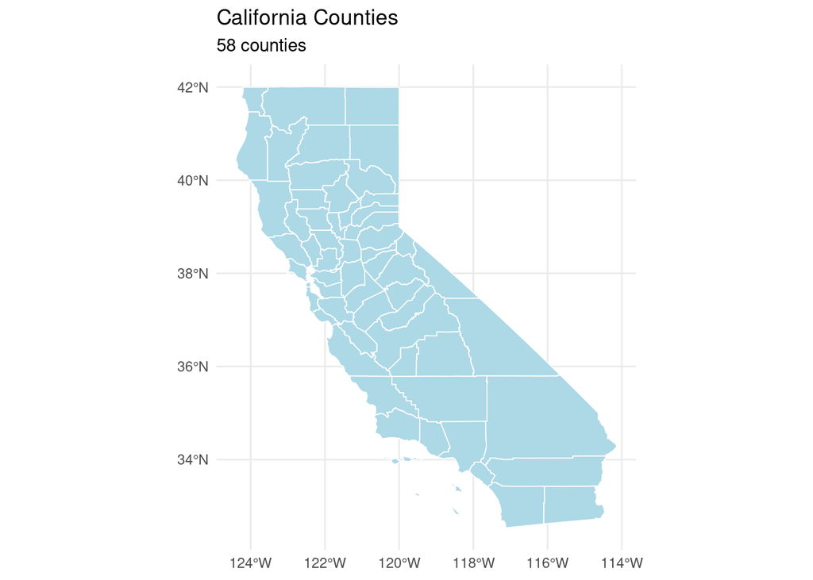

```r
# Visualize California counties
ggplot(ca_counties_sf) +
  geom_sf(fill = "lightblue", color = "white", size = 0.3) +
  theme_minimal() +
  labs(title = "California Counties",
       subtitle = paste(nrow(ca_counties_sf), "counties"))
```

## Step 2: Download gridMET Data

Now we’ll download gridMET data. For this example, we’ll download maximum temperature (tmmx) and precipitation (pr) for a specific time period.

```r
# Create a temporary directory for data storage
# In practice, you'd want to use a permanent location
print(getwd())
```

```
[1] "/ddn/gs1/home/messierkp/projects/amadeus/tutorials"
```

```r
data_dir <- file.path("tutorials", "gridmet_data")
dir.create(data_dir, showWarnings = FALSE, recursive = TRUE)

print(paste("Data will be saved to:", data_dir))
```

```
[1] "Data will be saved to: tutorials/gridmet_data"
```

### Download Maximum Temperature

```r
# Download maximum temperature data
# Note: This downloads data for 2023
download_data(
  dataset_name = "gridmet",
  variable = "tmmx",
  year = 2023,
  directory_to_save = data_dir,
  acknowledgement = TRUE,
  download = TRUE,
  remove_command = TRUE,
  hash = FALSE
)
```

### Download Precipitation

```r
# Download precipitation data
download_data(
  dataset_name = "gridmet",
  variable = "pr",
  year = 2023,
  directory_to_save = data_dir,
  acknowledgement = TRUE,
  download = TRUE,
  remove_command = TRUE,
  hash = FALSE
)
```

## Step 3: Process gridMET Data

After downloading, we need to process the raw netCDF files into `SpatRaster` objects that R can work with efficiently.

```r
# Process maximum temperature data
# Let's focus on summer months (June-August 2023)
tmmx_processed <- process_covariates(
  covariate = "gridmet",
  variable = "tmmx",
  date = c("2023-06-01", "2023-08-31"),
  path = file.path(data_dir, "tmmx")
)

# Process precipitation data
pr_processed <- process_covariates(
  covariate = "gridmet",
  variable = "pr",
  date = c("2023-06-01", "2023-08-31"),
  path = file.path(data_dir, "pr")
)

# View the processed data
print("Maximum Temperature SpatRaster:")
```

```
[1] "Maximum Temperature SpatRaster:"
```

```r
print(tmmx_processed)
```

```
class       : SpatRaster
size        : 585, 1386, 92  (nrow, ncol, nlyr)
resolution  : 0.04166667, 0.04166667  (x, y)
extent      : -124.7875, -67.0375, 25.04583, 49.42083  (xmin, xmax, ymin, ymax)
coord. ref. : lon/lat WGS 84 (EPSG:4326)
source      : tmmx_2023.nc
varname     : tmmx (maximum near-surface air temperature)
names       : tmmx_~30601, tmmx_~30602, tmmx_~30603, tmmx_~30604, tmmx_~30605, tmmx_~30606, ...
unit        : K
depth       : 45076 to 45167 (day [days since 1900-01-01 00:00:00]: 92 steps)
time (days) : 2023-06-01 to 2023-08-31 (92 steps)
```

```r
print("Precipitation SpatRaster:")
```

```
[1] "Precipitation SpatRaster:"
```

```r
print(pr_processed)
```

```
class       : SpatRaster
size        : 585, 1386, 92  (nrow, ncol, nlyr)
resolution  : 0.04166667, 0.04166667  (x, y)
extent      : -124.7875, -67.0375, 25.04583, 49.42083  (xmin, xmax, ymin, ymax)
coord. ref. : lon/lat WGS 84 (EPSG:4326)
source      : pr_2023.nc
varname     : pr (precipitation)
names       : pr_20230601, pr_20230602, pr_20230603, pr_20230604, pr_20230605, pr_20230606, ...
unit        : mm
depth       : 45076 to 45167 (day [days since 1900-01-01 00:00:00]: 92 steps)
time (days) : 2023-06-01 to 2023-08-31 (92 steps)
```

**Understanding SpatRaster**

The `SpatRaster` object contains multiple layers - one for each day in our date range. The `terra` package provides powerful tools for working with these multi-layer raster datasets.

## Step 4: Extract Values at County Locations

Now we’ll extract the gridMET values for our counties using their polygon boundaries.

```r
# Extract maximum temperature values using county polygons
# This calculates zonal statistics across the entire county area
tmmx_counties <- calculate_gridmet(
  from = tmmx_processed,
  locs = ca_counties_sf,
  locs_id = "GEOID",
  radius = 0,
  fun = "mean",
  geom = FALSE
)

# Extract precipitation values using county polygons
pr_counties <- calculate_gridmet(
  from = pr_processed,
  locs = ca_counties_sf,
  locs_id = "GEOID",
  radius = 0,
  fun = "mean",
  geom = FALSE
)

# View results
head(tmmx_counties)
```

```
  GEOID       time   tmmx_0
1 06037 2023-06-01 291.4795
2 06097 2023-06-01 296.9167
3 06001 2023-06-01 293.9514
4 06045 2023-06-01 295.6541
5 06015 2023-06-01 291.8811
6 06055 2023-06-01 298.1182
```

```r
head(pr_counties)
```

```
  GEOID       time      pr_0
1 06037 2023-06-01 0.1140034
2 06097 2023-06-01 0.0000000
3 06001 2023-06-01 0.0000000
4 06045 2023-06-01 0.0000000
5 06015 2023-06-01 0.0000000
6 06055 2023-06-01 0.0000000
```

**Polygon-based Extraction**

By passing the polygon geometries directly (instead of centroids), `calculate_gridmet()` performs **zonal statistics** - calculating the mean across all grid cells within each county boundary. This provides a much more accurate representation than point extraction, especially for large counties.

## Step 5: Data Analysis and Visualization

### Reshape and Summarize Data

```r
# Combine temperature and precipitation data
# Note: calculate_gridmet returns data in long format with a 'time' column
# and variable columns (e.g., 'tmmx_0' for temperature at 0m radius)

# Check the structure
cat("Temperature data structure:\n")
```

```
Temperature data structure:
```

```r
str(tmmx_counties)
```

```
'data.frame':   5336 obs. of  3 variables:
 $ GEOID : chr  "06037" "06097" "06001" "06045" ...
 $ time  : POSIXct, format: "2023-06-01" "2023-06-01" ...
 $ tmmx_0: num  291 297 294 296 292 ...
```

```r
cat("\nPrecipitation data structure:\n")
```

```
Precipitation data structure:
```

```r
str(pr_counties)
```

```
'data.frame':   5336 obs. of  3 variables:
 $ GEOID: chr  "06037" "06097" "06001" "06045" ...
 $ time : POSIXct, format: "2023-06-01" "2023-06-01" ...
 $ pr_0 : num  0.114 0 0 0 0 ...
```

```r
# Convert time column to Date and rename variable columns
tmmx_long <- tmmx_counties %>%
  mutate(date = as.Date(time)) %>%
  rename(tmax_k = tmmx_0) %>%
  mutate(tmax_c = tmax_k - 273.15) %>%  # Convert Kelvin to Celsius
  select(-time, -tmax_k)

pr_long <- pr_counties %>%
  mutate(date = as.Date(time)) %>%
  rename(precip_mm = pr_0) %>%
  select(-time)

# Merge datasets
weather_data <- tmmx_long %>%
  left_join(pr_long, by = c("GEOID", "date")) %>%
  left_join(
    ca_counties_sf %>% st_drop_geometry() %>% select(GEOID, county_name),
    by = "GEOID"
  )

# Calculate summer statistics by county
summer_stats <- weather_data %>%
  group_by(GEOID, county_name) %>%
  summarize(
    mean_tmax_c = mean(tmax_c, na.rm = TRUE),
    max_tmax_c = max(tmax_c, na.rm = TRUE),
    total_precip_mm = sum(precip_mm, na.rm = TRUE),
    days_over_35c = sum(tmax_c > 35, na.rm = TRUE),
    .groups = "drop"
  )

# View hottest counties
summer_stats %>%
  arrange(desc(mean_tmax_c)) %>%
  head(10)
```

```
# A tibble: 10 × 6
   GEOID county_name    mean_tmax_c max_tmax_c total_precip_mm days_over_35c
   <chr> <chr>                <dbl>      <dbl>           <dbl>         <int>
 1 06025 Imperial              40.3       47.2          46.6              78
 2 06065 Riverside             36.0       42.8          69.8              59
 3 06071 San Bernardino        35.6       43.6          69.4              56
 4 06031 Kings                 35.3       42.7          11.0              51
 5 06101 Sutter                33.8       41.7           3.28             39
 6 06047 Merced                33.7       41.3           1.95             41
 7 06113 Yolo                  33.3       41.3           0.212            34
 8 06011 Colusa                33.3       40.7           4.50             30
 9 06099 Stanislaus            32.8       40.4           0.675            32
10 06077 San Joaquin           32.7       40.7           0.163            34
```

### Visualize Temperature Patterns

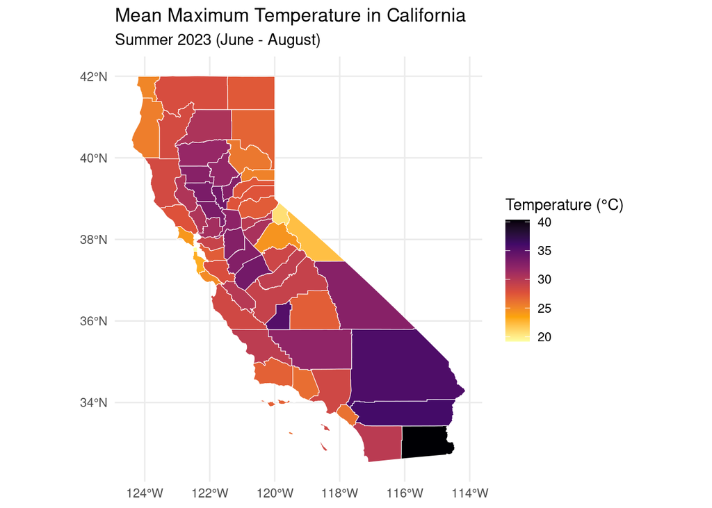

```r
# Join summer statistics with county geometry for mapping
ca_summer_map <- ca_counties_sf %>%
  left_join(summer_stats, by = "GEOID")

# Map mean maximum temperature
ggplot(ca_summer_map) +
  geom_sf(aes(fill = mean_tmax_c), color = "white", size = 0.2) +
  scale_fill_viridis_c(option = "inferno", direction = -1) +
  theme_minimal() +
  labs(
    title = "Mean Maximum Temperature in California",
    subtitle = "Summer 2023 (June - August)",
    fill = "Temperature (°C)"
  )
```

### Time Series for Selected Counties

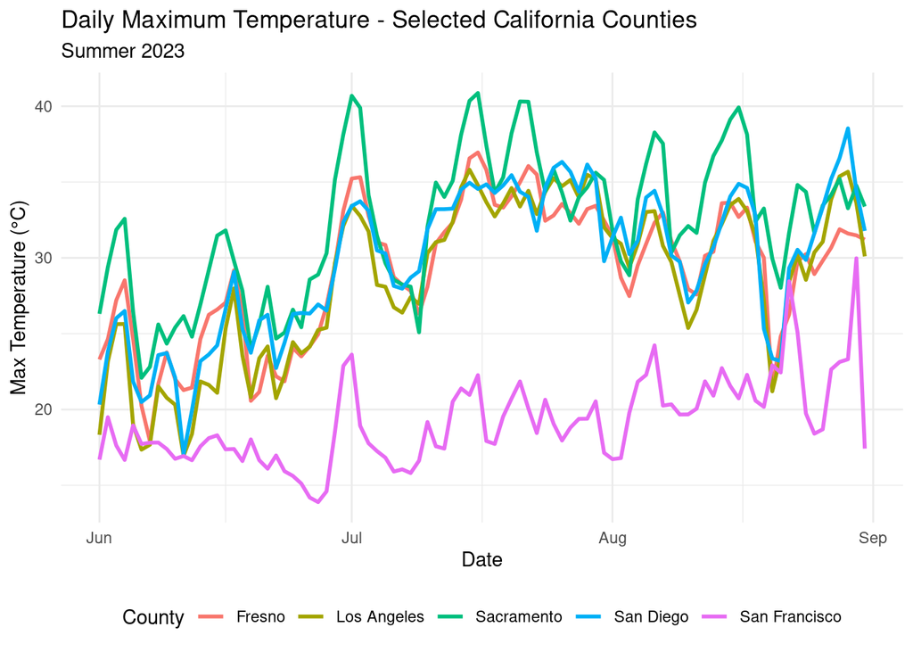

```r
# Select a few representative counties
selected_counties <- c("Los Angeles", "San Francisco",
                      "Sacramento", "San Diego", "Fresno")

weather_subset <- weather_data %>%
  filter(county_name %in% selected_counties)

# Temperature time series
ggplot(weather_subset, aes(x = date, y = tmax_c, color = county_name)) +
  geom_line(linewidth = 1) +
  theme_minimal() +
  labs(
    title = "Daily Maximum Temperature - Selected California Counties",
    subtitle = "Summer 2023",
    x = "Date",
    y = "Max Temperature (°C)",
    color = "County"
  ) +
  theme(legend.position = "bottom")
```

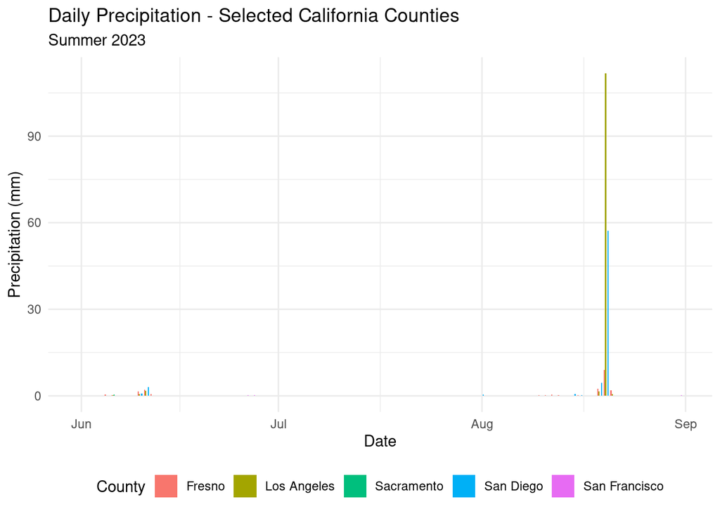

```r
# Precipitation time series
ggplot(weather_subset, aes(x = date, y = precip_mm, fill = county_name)) +
  geom_col(position = "dodge") +
  theme_minimal() +
  labs(
    title = "Daily Precipitation - Selected California Counties",
    subtitle = "Summer 2023",
    x = "Date",
    y = "Precipitation (mm)",
    fill = "County"
  ) +
  theme(legend.position = "bottom")
```

### Analyze Extreme Heat Days

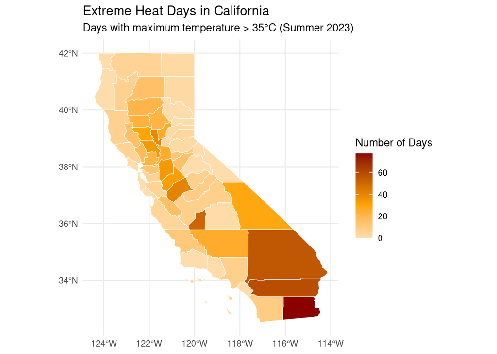

```r
# Map days over 35°C (95°F)
ggplot(ca_summer_map) +
  geom_sf(aes(fill = days_over_35c), color = "white", size = 0.2) +
  scale_fill_gradient2(
    low = "white",
    mid = "orange",
    high = "darkred",
    midpoint = 30
  ) +
  theme_minimal() +
  labs(
    title = "Extreme Heat Days in California",
    subtitle = "Days with maximum temperature > 35°C (Summer 2023)",
    fill = "Number of Days"
  )
```

## Step 6: H3 Hexagonal Spatial Analysis

Instead of using county boundaries, we can analyze spatial patterns using H3 hexagons - a hierarchical spatial indexing system that provides uniform hexagonal grids.

### Setup H3

```r
# Install and load h3 package
library(h3jsr)
```

### Create H3 Grid for California

```r
# Generate H3 hexagons at resolution 6 covering California
# Resolution 6 creates hexagons approximately 36 km² in area

# Ensure California counties are in WGS84
ca_counties_wgs84 <- st_transform(ca_counties_sf, 4326)

# Get the bounding box and create a simple polygon
ca_bbox <- st_bbox(ca_counties_wgs84)
bbox_poly <- st_as_sfc(ca_bbox) %>%
  st_sf() %>%
  st_set_crs(4326)

# Generate H3 cells for the bounding box
ca_h3_ids <- polygon_to_cells(bbox_poly, res = 6, simple = TRUE)

cat(paste("Generated", length(ca_h3_ids), "H3 hexagons at resolution 6\n"))
```

```
Generated 1 H3 hexagons at resolution 6
```

```r
# Convert H3 cells to sf polygons and explicitly set CRS
h3_grid <- cell_to_polygon(ca_h3_ids, simple = FALSE) %>%
  st_set_crs(4326)

# Intersect with California to keep only hexagons that overlap the state
h3_grid_ca <- st_intersection(h3_grid, st_union(ca_counties_wgs84))

cat(paste("After filtering:", nrow(h3_grid_ca), "hexagons within California\n"))
```

```
After filtering: 11025 hexagons within California
```

```r
# Update h3_cells to match filtered grid
h3_cells <- h3_grid_ca$h3_address

# Create centroids for data extraction
h3_centroids <- st_centroid(h3_grid_ca) %>%
  mutate(
    h3_id = h3_cells,
    lon = st_coordinates(.)[,1],
    lat = st_coordinates(.)[,2]
  ) %>%
  st_drop_geometry() %>%
  select(h3_id, lon, lat)

# Use filtered grid for visualization
h3_grid <- h3_grid_ca

head(h3_centroids)
```

```
             h3_id       lon      lat
2  862832b6fffffff -121.7726 38.60394
6  8628026e7ffffff -123.4726 41.26784
9  8629a1a17ffffff -118.8833 34.41408
12 86281529fffffff -122.5020 40.77603
13 8628306d7ffffff -121.9807 38.76689
18 8629a9da7ffffff -120.4027 36.20066
```

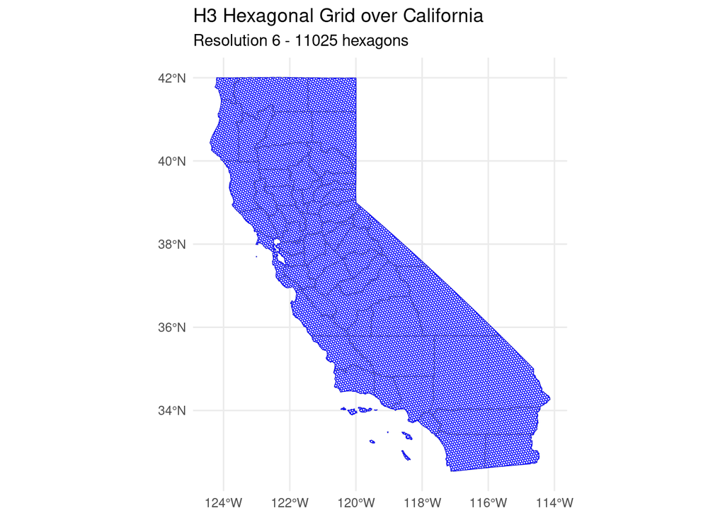

```r
# Visualize H3 grid over California
ggplot() +
  geom_sf(data = ca_counties_sf, fill = NA, color = "gray60", size = 0.3) +
  geom_sf(data = h3_grid, fill = NA, color = "blue", size = 0.2, alpha = 0.5) +
  theme_minimal() +
  labs(
    title = "H3 Hexagonal Grid over California",
    subtitle = paste("Resolution 6 -", length(h3_cells), "hexagons")
  )
```

### Extract GridMET Data for H3 Hexagons

```r
# Extract temperature using H3 hexagon polygons
# This performs zonal statistics across each hexagon
tmmx_h3 <- calculate_gridmet(
  from = tmmx_processed,
  locs = h3_grid,
  locs_id = "h3_address",
  radius = 0,
  fun = "mean",
  geom = FALSE
)

# Extract precipitation using H3 hexagon polygons
pr_h3 <- calculate_gridmet(
  from = pr_processed,
  locs = h3_grid,
  locs_id = "h3_address",
  radius = 0,
  fun = "mean",
  geom = FALSE
)

head(tmmx_h3)
```

```
       h3_address       time   tmmx_0
1 862832b6fffffff 2023-06-01 300.6355
2 8628026e7ffffff 2023-06-01 294.2859
3 8629a1a17ffffff 2023-06-01 286.4971
4 86281529fffffff 2023-06-01 297.0399
5 8628306d7ffffff 2023-06-01 302.0372
6 8629a9da7ffffff 2023-06-01 301.7668
```

### Process and Aggregate H3 Data

```r
# Process H3 temperature data
tmmx_h3_long <- tmmx_h3 %>%
  mutate(date = as.Date(time)) %>%
  rename(tmax_k = tmmx_0) %>%
  mutate(tmax_c = tmax_k - 273.15) %>%
  select(-time, -tmax_k)

# Process H3 precipitation data
pr_h3_long <- pr_h3 %>%
  mutate(date = as.Date(time)) %>%
  rename(precip_mm = pr_0) %>%
  select(-time)

# Merge H3 data
h3_weather_data <- tmmx_h3_long %>%
  left_join(pr_h3_long, by = c("h3_address", "date"))

# Calculate summer statistics by H3 hexagon
h3_summer_stats <- h3_weather_data %>%
  group_by(h3_address) %>%
  summarize(
    mean_tmax_c = mean(tmax_c, na.rm = TRUE),
    max_tmax_c = max(tmax_c, na.rm = TRUE),
    total_precip_mm = sum(precip_mm, na.rm = TRUE),
    days_over_35c = sum(tmax_c > 35, na.rm = TRUE),
    .groups = "drop"
  )

head(h3_summer_stats)
```

```
# A tibble: 6 × 5
  h3_address      mean_tmax_c max_tmax_c total_precip_mm days_over_35c
  <chr>                 <dbl>      <dbl>           <dbl>         <int>
1 862800407ffffff        25.6       36.3            5.10             1
2 86280040fffffff        21.6       30.1            5.16             0
3 862800417ffffff        26.2       37.3            7.52             3
4 86280041fffffff        24.2       34.9            6.11             0
5 862800427ffffff        22.9       34.2            4.36             0
6 86280042fffffff        22.0       32.3            3.66             0
```

### Visualize Spatial Patterns with H3 Hexagons

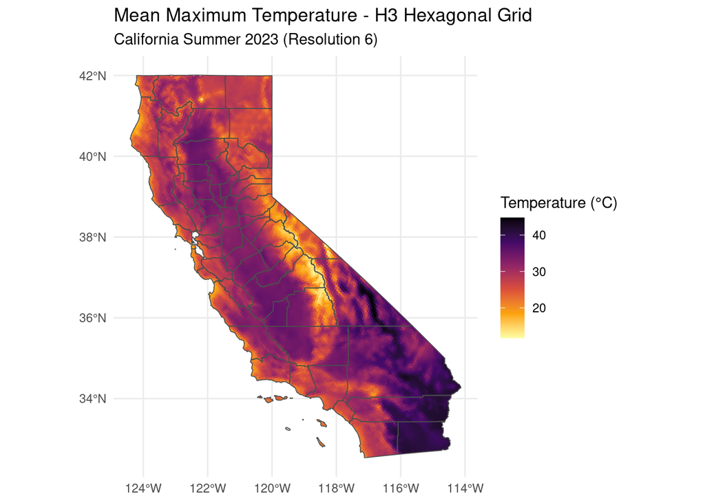

```r
# Join statistics with H3 grid geometry
h3_summer_map <- h3_grid %>%
  left_join(h3_summer_stats, by = "h3_address")

# Map mean temperature with H3 hexagons
ggplot(h3_summer_map) +
  geom_sf(aes(fill = mean_tmax_c), color = NA) +
  geom_sf(data = ca_counties_sf, fill = NA, color = "gray30", size = 0.3) +
  scale_fill_viridis_c(option = "inferno", direction = -1, na.value = "gray90") +
  theme_minimal() +
  labs(
    title = "Mean Maximum Temperature - H3 Hexagonal Grid",
    subtitle = "California Summer 2023 (Resolution 6)",
    fill = "Temperature (°C)"
  )
```

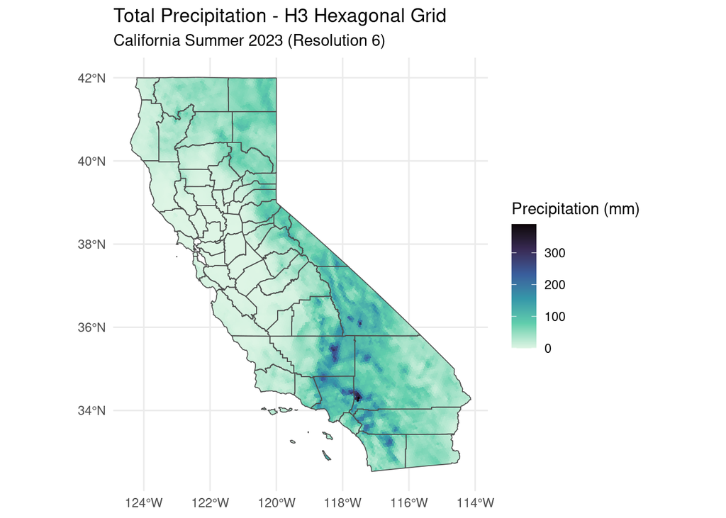

```r
# Map total precipitation with H3 hexagons
ggplot(h3_summer_map) +
  geom_sf(aes(fill = total_precip_mm), color = NA) +
  geom_sf(data = ca_counties_sf, fill = NA, color = "gray30", size = 0.3) +
  scale_fill_viridis_c(option = "mako", direction = -1, na.value = "gray90") +
  theme_minimal() +
  labs(
    title = "Total Precipitation - H3 Hexagonal Grid",
    subtitle = "California Summer 2023 (Resolution 6)",
    fill = "Precipitation (mm)"
  )
```

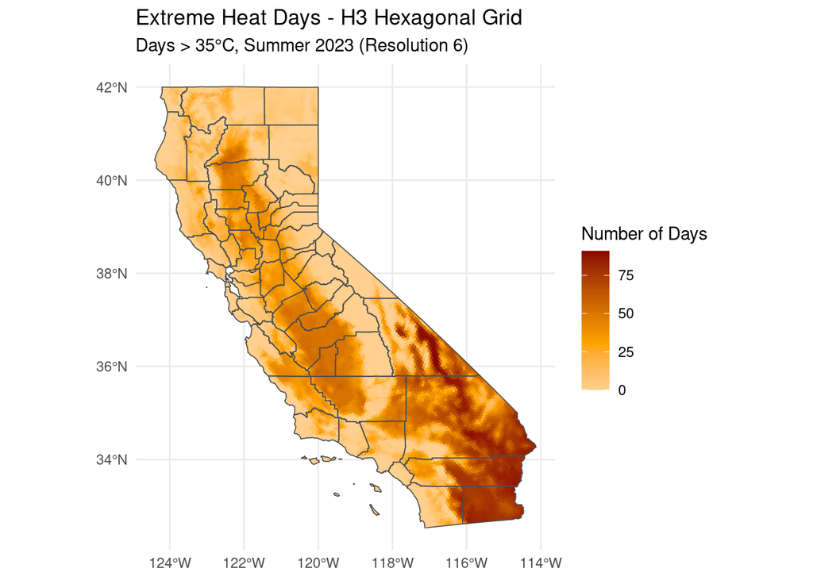

```r
# Map extreme heat days with H3 hexagons
ggplot(h3_summer_map) +
  geom_sf(aes(fill = days_over_35c), color = NA) +
  geom_sf(data = ca_counties_sf, fill = NA, color = "gray30", size = 0.3) +
  scale_fill_gradient2(
    low = "white",
    mid = "orange",
    high = "darkred",
    midpoint = 30,
    na.value = "gray90"
  ) +
  theme_minimal() +
  labs(
    title = "Extreme Heat Days - H3 Hexagonal Grid",
    subtitle = "Days > 35°C, Summer 2023 (Resolution 6)",
    fill = "Number of Days"
  )
```

**Why Use H3 Hexagons?**

**Advantages over administrative boundaries:**

- **Uniform sampling**: Each hexagon has equal area (~36 km² at resolution 6)
- **No edge effects**: Hexagons have equal distance to all 6 neighbors
- **Better spatial patterns**: Reveals gradients not visible with irregular county boundaries
- **Hierarchical**: Easy to aggregate/disaggregate between resolutions
- **Consistent**: Same grid system works globally

H3 hexagons provide a more uniform and statistically robust way to visualize spatial patterns in climate data.

## Summary and Next Steps

### Next Steps

- **Expand temporal coverage**: Download data for multiple years to analyze trends
- **Add more variables**: Explore other gridMET variables like humidity, solar radiation, or wind speed
- **Refine spatial analysis**: Use buffers or zonal statistics for more sophisticated extraction methods
- **Statistical modeling**: Use the extracted data as covariates in epidemiological or environmental models
- **Automate workflows**: Create scripts to regularly update data and generate reports

### Additional Resources

- [gridMET Documentation](https://www.climatologylab.org/gridmet.html)
- [Amadeus Package Website](https://niehs.github.io/amadeus/)
- [gridMET Variable Reference](https://www.climatologylab.org/wget-gridmet.html)
- [Terra Package Documentation](https://rspatial.github.io/terra/)